# Agoda Case Testing

### Fixing on 11/24, 11/25, 11/26, 11/27 (Thanksgiveing/Black Friday long weekend)

note: only the records of "Hotel" type

```python
##### 11/24/2016
exA_thanksblack_1124 = exA_thanksblack[exA_thanksblack['checkin_date'] == thanksblack[0]]
exA_thanksblack_1124_ahead_ADR = exA_thanksblack_1124[exA_thanksblack_1124['accommadation_type_name'] == 'Hotel'].groupby([exA_thanksblack_1124['bookdays_int']]).agg('mean').iloc[:, [1, 5]]
exA_thanksblack_1124_ahead_ADR['booking_records'] = exA_thanksblack_1124.groupby(exA_thanksblack_1124['bookdays_int']).agg('count')['#']

##### 11/25/2016
exA_thanksblack_1125 = exA_thanksblack[exA_thanksblack['checkin_date'] == thanksblack[1]]
exA_thanksblack_1125_ahead_ADR = exA_thanksblack_1125[exA_thanksblack_1125['accommadation_type_name'] == 'Hotel'].groupby([exA_thanksblack_1125['bookdays_int']]).agg('mean').iloc[:, [1, 5]]
exA_thanksblack_1125_ahead_ADR['booking_records'] = exA_thanksblack_1125.groupby(exA_thanksblack_1125['bookdays_int']).agg('count')['#']


##### 11/26/2016
exA_thanksblack_1126 = exA_thanksblack[exA_thanksblack['checkin_date'] == thanksblack[2]]
exA_thanksblack_1126_ahead_ADR = exA_thanksblack_1126[exA_thanksblack_1126['accommadation_type_name'] == 'Hotel'].groupby([exA_thanksblack_1126['bookdays_int']]).agg('mean').iloc[:, [1, 5]]
exA_thanksblack_1126_ahead_ADR['booking_records'] = exA_thanksblack_1126.groupby(exA_thanksblack_1126['bookdays_int']).agg('count')['#']


##### 11/27/2016
exA_thanksblack_1127 = exA_thanksblack[exA_thanksblack['checkin_date'] == thanksblack[3]]
exA_thanksblack_1127_ahead_ADR = exA_thanksblack_1127[exA_thanksblack_1127['accommadation_type_name'] == 'Hotel'].groupby([exA_thanksblack_1127['bookdays_int']]).agg('mean').iloc[:, [1, 5]]
exA_thanksblack_1127_ahead_ADR['booking_records'] = exA_thanksblack_1127.groupby(exA_thanksblack_1127['bookdays_int']).agg('count')['#']
```

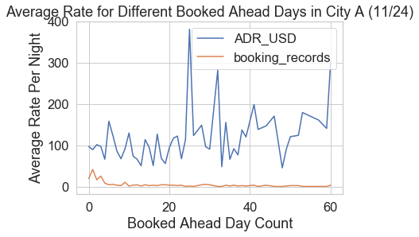

```python
book_ahead_h_1124 = plt.figure(figsize=(8, 6))
exA_thanksblack_1124_ahead_ADR[['ADR_USD', 'booking_records']].plot(kind = "line")
plt.xlabel("Booked Ahead Day Count")
plt.ylabel("Average Rate Per Night");
plt.title("Average Rate for Different Booked Ahead Days in City A (11/24)")
book_ahead_h_1124.savefig('Pictures/book_ahead_h_1124.png')
```

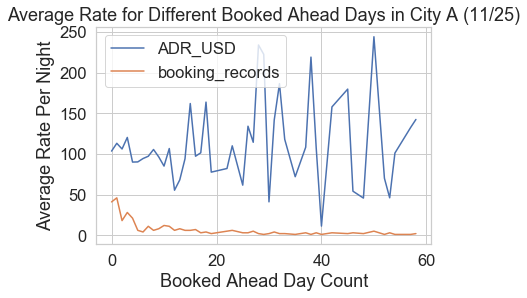

```python
book_ahead_h_1125 = plt.figure(figsize=(8, 6))
exA_thanksblack_1125_ahead_ADR[['ADR_USD', 'booking_records']].plot(kind = "line")
plt.xlabel("Booked Ahead Day Count")
plt.ylabel("Average Rate Per Night");
plt.title("Average Rate for Different Booked Ahead Days in City A (11/25)")
book_ahead_h_1125.savefig('Pictures/book_ahead_h_1125.png')
```

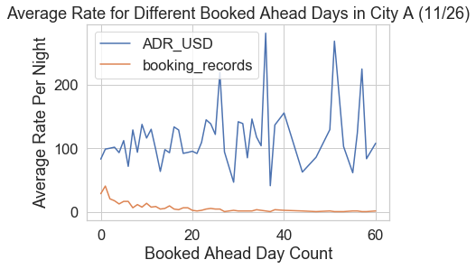

```python
book_ahead_h_1126 = plt.figure(figsize=(8, 6))
exA_thanksblack_1126_ahead_ADR[['ADR_USD', 'booking_records']].plot(kind = "line")
plt.xlabel("Booked Ahead Day Count")
plt.ylabel("Average Rate Per Night");
plt.title("Average Rate for Different Booked Ahead Days in City A (11/26)")
book_ahead_h_1126.savefig('Pictures/book_ahead_h_1126.png')
```

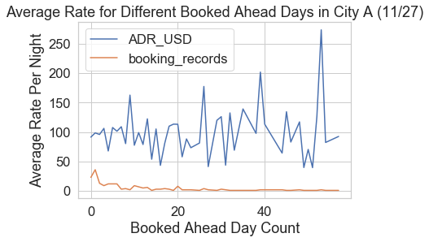

```python
book_ahead_h_1127 = plt.figure(figsize=(8, 6))
exA_thanksblack_1127_ahead_ADR[['ADR_USD', 'booking_records']].plot(kind = "line")
plt.xlabel("Booked Ahead Day Count")
plt.ylabel("Average Rate Per Night");
plt.title("Average Rate for Different Booked Ahead Days in City A (11/27)")
book_ahead_h_1127.savefig('Pictures/book_ahead_h_1127.png')
```

### Fixing on 12/23, 12/24, 12/25, 12/26 (Christmas long weekend)

note: only the records of "Hotel" type

```python
##### 12/23/2016
exA_christmas_1223 = exA_christmas[exA_christmas['checkin_date'] == christmas[0]]
exA_christmas_1223_ahead_ADR = exA_christmas_1223[exA_christmas_1223['accommadation_type_name'] == 'Hotel'].groupby([exA_christmas_1223['bookdays_int']]).agg('mean').iloc[:, [1, 5]]
exA_christmas_1223_ahead_ADR['booking_records'] = exA_christmas_1223.groupby(exA_christmas_1223['bookdays_int']).agg('count')['#']


##### 12/24/2016
exA_christmas_1224 = exA_christmas[exA_christmas['checkin_date'] == christmas[1]]
exA_christmas_1224_ahead_ADR = exA_christmas_1224[exA_christmas_1224['accommadation_type_name'] == 'Hotel'].groupby([exA_christmas_1224['bookdays_int']]).agg('mean').iloc[:, [1, 5]]
exA_christmas_1224_ahead_ADR['booking_records'] = exA_christmas_1224.groupby(exA_christmas_1224['bookdays_int']).agg('count')['#']


##### 12/25/2016
exA_christmas_1225 = exA_christmas[exA_christmas['checkin_date'] == christmas[2]]
exA_christmas_1225_ahead_ADR = exA_christmas_1225[exA_christmas_1225['accommadation_type_name'] == 'Hotel'].groupby([exA_christmas_1225['bookdays_int']]).agg('mean').iloc[:, [1, 5]]
exA_christmas_1225_ahead_ADR['booking_records'] = exA_christmas_1225.groupby(exA_christmas_1225['bookdays_int']).agg('count')['#']


##### 12/26/2016
exA_christmas_1226 = exA_christmas[exA_christmas['checkin_date'] == christmas[3]]
exA_christmas_1226_ahead_ADR = exA_christmas_1226[exA_christmas_1226['accommadation_type_name'] == 'Hotel'].groupby([exA_christmas_1226['bookdays_int']]).agg('mean').iloc[:, [1, 5]]
exA_christmas_1226_ahead_ADR['booking_records'] = exA_christmas_1226.groupby(exA_christmas_1226['bookdays_int']).agg('count')['#']
```

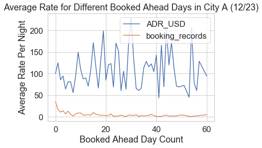

```python
book_ahead_h_1223 = plt.figure(figsize=(8, 6))
exA_christmas_1223_ahead_ADR[['ADR_USD', 'booking_records']].plot(kind = "line")
plt.xlabel("Booked Ahead Day Count")
plt.ylabel("Average Rate Per Night");
plt.title("Average Rate for Different Booked Ahead Days in City A (12/23)")
book_ahead_h_1223.savefig('Pictures/book_ahead_h_1223.png')
```

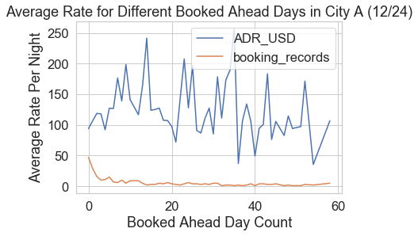

```python
book_ahead_h_1224 = plt.figure(figsize=(20, 20))
exA_christmas_1224_ahead_ADR[['ADR_USD', 'booking_records']].plot(kind = "line")
plt.xlabel("Booked Ahead Day Count")
plt.ylabel("Average Rate Per Night");
plt.title("Average Rate for Different Booked Ahead Days in City A (12/24)")
book_ahead_h_1224.savefig('Pictures/book_ahead_h_1224.png')
```

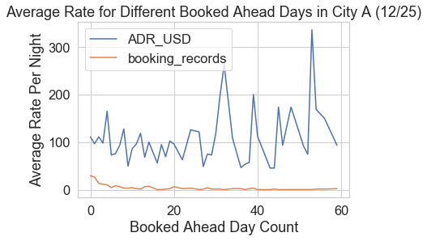

```python
book_ahead_h_1225 = plt.figure(figsize=(20, 20))
exA_christmas_1225_ahead_ADR[['ADR_USD', 'booking_records']].plot(kind = "line")
plt.xlabel("Booked Ahead Day Count")
plt.ylabel("Average Rate Per Night");
plt.title("Average Rate for Different Booked Ahead Days in City A (12/25)")
book_ahead_h_1225.savefig('Pictures/book_ahead_h_1225.png')
```

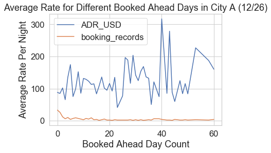

```python
book_ahead_h_1226 = plt.figure(figsize=(15, 10))
exA_christmas_1226_ahead_ADR[['ADR_USD', 'booking_records']].plot(kind = "line")
plt.xlabel("Booked Ahead Day Count")
plt.ylabel("Average Rate Per Night");
plt.title("Average Rate for Different Booked Ahead Days in City A (12/26)")
book_ahead_h_1226.savefig('Pictures/book_ahead_h_1226.png')
```

What will be the difference if we fixed the checkin date on a regular date? (Not holiday)  
*In order to compare the price movement as the day approaches a **Holiday** with the price movement as the day approaches a random **Normal Day**. Let's use the following random day:*

### Random Fixed Date (10/03, 11/30, 12/10, 12/13)

```python
random_date = [date(2016, 10, 3), date(2016, 11, 30), date(2016, 12, 10), date(2016, 12, 13)]
random_date

##### 10/03/2016
exA_random_1003 = exA[exA['checkin_date'] == random_date[0]]
exA_random_1003_ahead_ADR = exA_random_1003[exA_random_1003['accommadation_type_name'] == 'Hotel'].groupby([exA_random_1003['bookdays_int']]).agg('mean').iloc[:, [1, 5]]
exA_random_1003_ahead_ADR['booking_records'] = exA_random_1003.groupby(exA_random_1003['bookdays_int']).agg('count')['#']


##### 11/30/2016
exA_random_1130 = exA[exA['checkin_date'] == random_date[1]]
exA_random_1130_ahead_ADR = exA_random_1130[exA_random_1130['accommadation_type_name'] == 'Hotel'].groupby([exA_random_1130['bookdays_int']]).agg('mean').iloc[:, [1, 5]]
exA_random_1130_ahead_ADR['booking_records'] = exA_random_1130.groupby(exA_random_1130['bookdays_int']).agg('count')['#']


##### 12/10/2016
exA_random_1210 = exA[exA['checkin_date'] == random_date[2]]
exA_random_1210_ahead_ADR = exA_random_1210[exA_random_1210['accommadation_type_name'] == 'Hotel'].groupby([exA_random_1210['bookdays_int']]).agg('mean').iloc[:, [1, 5]]
exA_random_1210_ahead_ADR['booking_records'] = exA_random_1210.groupby(exA_random_1210['bookdays_int']).agg('count')['#']

##### 12/13/2016
exA_random_1213 = exA[exA['checkin_date'] == random_date[3]]
exA_random_1213_ahead_ADR = exA_random_1213[exA_random_1213['accommadation_type_name'] == 'Hotel'].groupby([exA_random_1213['bookdays_int']]).agg('mean').iloc[:, [1, 5]]
exA_random_1213_ahead_ADR['booking_records'] = exA_random_1213.groupby(exA_random_1213['bookdays_int']).agg('count')['#']
```

```
[datetime.date(2016, 10, 3),
 datetime.date(2016, 11, 30),
 datetime.date(2016, 12, 10),
 datetime.date(2016, 12, 13)]
```

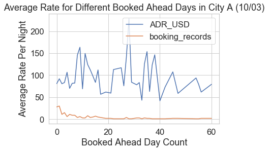

```python
book_ahead_1003 = plt.figure(figsize=(8, 6))
exA_random_1003_ahead_ADR[['ADR_USD', 'booking_records']].plot(kind = "line")
plt.xlabel("Booked Ahead Day Count")
plt.ylabel("Average Rate Per Night");
plt.title("Average Rate for Different Booked Ahead Days in City A (10/03)")
book_ahead_1003.savefig('Pictures/book_ahead_1003.png')
```

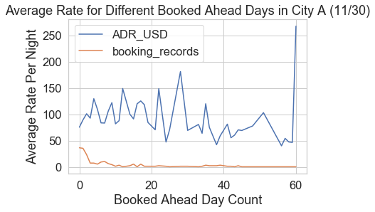

```python
book_ahead_1130 = plt.figure(figsize=(8, 6))
exA_random_1130_ahead_ADR[['ADR_USD', 'booking_records']].plot(kind = "line")
plt.xlabel("Booked Ahead Day Count")
plt.ylabel("Average Rate Per Night");
plt.title("Average Rate for Different Booked Ahead Days in City A (11/30)")
book_ahead_1130.savefig('Pictures/book_ahead_1130.png')
```

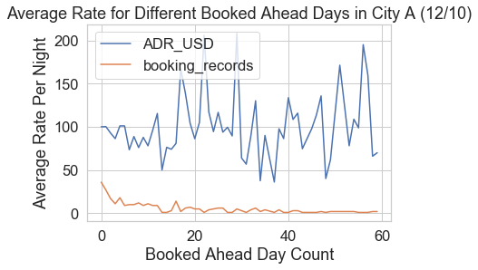

```python
book_ahead_1210 = plt.figure(figsize=(8, 6))
exA_random_1210_ahead_ADR[['ADR_USD', 'booking_records']].plot(kind = "line")
plt.xlabel("Booked Ahead Day Count")
plt.ylabel("Average Rate Per Night");
plt.title("Average Rate for Different Booked Ahead Days in City A (12/10)")
book_ahead_1210.savefig('Pictures/book_ahead_1210.png')
```

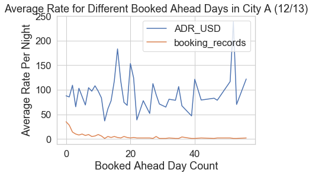

```python
book_ahead_1213 = plt.figure(figsize=(8, 6))
exA_random_1213_ahead_ADR[['ADR_USD', 'booking_records']].plot(kind = "line")
plt.xlabel("Booked Ahead Day Count")
plt.ylabel("Average Rate Per Night");
plt.title("Average Rate for Different Booked Ahead Days in City A (12/13)")
book_ahead_1213.savefig('Pictures/book_ahead_1213.png')
```

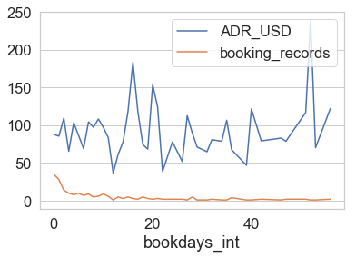

```python
exA_random_1213_ahead_ADR['booking_records'] = exA_random_1213.groupby(exA_random_1213['bookdays_int']).agg('count')['#']
# exA_random_1213_ahead_ADR
plt.figure(figsize=(15, 10))
exA_random_1213_ahead_ADR[['ADR_USD', 'booking_records']].plot()
```

In order for the price (ADR_USD) to avoid the affect from having too many kinds of hotel (too many different rates), let's focus on 1 specific "Hotel" for now. This way maybe the plot will provide an more obvious evidence.  
Let's use the hotel that has the most booking records for the specific checkin date. (The most popular)

### One Hotel For Thanksgiving/Black Friday Long Weekend

```python
pop_hotel_1124 = exA_thanksblack_1124.groupby(exA_thanksblack_1124['hotel_id']).agg('count')['#'].sort_values(ascending = False).head(1).index[0]
pop_hotel_1124
exA_thanksblack_1124[exA_thanksblack_1124['hotel_id'] == pop_hotel_1124].head()
len(exA_thanksblack_1124[exA_thanksblack_1124['hotel_id'] == pop_hotel_1124])
```

```
197996
```

|  | # | ADR_USD | hotel_id | city_id | star_rating | accommadation_type_name | chain_hotel | booking_date | checkin_date | checkout_date | booking_month | checkin_month | booked_days_ahead | bookdays_int | day_of_week |
| --- | --- | --- | --- | --- | --- | --- | --- | --- | --- | --- | --- | --- | --- | --- | --- |
| 3393 | 3394 | 66.16 | 197996 | 9395 | 3.5 | Hotel | non-chain | 2016-10-03 | 2016-11-24 | 2016-11-25 | 10 | 11 | 52 days | 52 | Thursday |
| 4085 | 4086 | 59.84 | 197996 | 9395 | 3.5 | Hotel | non-chain | 2016-10-05 | 2016-11-24 | 2016-11-25 | 10 | 11 | 50 days | 50 | Thursday |
| 4389 | 4390 | 44.24 | 197996 | 9395 | 3.5 | Hotel | non-chain | 2016-10-06 | 2016-11-24 | 2016-11-25 | 10 | 11 | 49 days | 49 | Thursday |
| 4484 | 4485 | 45.86 | 197996 | 9395 | 3.5 | Hotel | non-chain | 2016-10-07 | 2016-11-24 | 2016-11-25 | 10 | 11 | 48 days | 48 | Thursday |
| 6578 | 6579 | 38.98 | 197996 | 9395 | 3.5 | Hotel | non-chain | 2016-10-16 | 2016-11-24 | 2016-11-25 | 10 | 11 | 39 days | 39 | Thursday |

```
34
```

```python
##### 11/24/2016
exA_thanksblack_1124 = exA_thanksblack[exA_thanksblack['checkin_date'] == thanksblack[0]]
pop_hotel_1124 = exA_thanksblack_1124.groupby(exA_thanksblack_1124['hotel_id']).agg('count')['#'].sort_values(ascending = False).head(1).index[0]

exA_thanksblack_1124_ahead_ADR_pophotel = exA_thanksblack_1124[exA_thanksblack_1124['hotel_id'] == pop_hotel_1124].groupby([exA_thanksblack_1124['bookdays_int']]).agg('mean').iloc[:, [1, 4, 5]]
exA_thanksblack_1124_ahead_ADR_pophotel['booking_records'] = exA_thanksblack_1124[exA_thanksblack_1124['hotel_id'] == pop_hotel_1124].groupby('bookdays_int').agg('count')['#']

# ##### 11/25/2016
exA_thanksblack_1125 = exA_thanksblack[exA_thanksblack['checkin_date'] == thanksblack[1]]
pop_hotel_1125 = exA_thanksblack_1125.groupby(exA_thanksblack_1125['hotel_id']).agg('count')['#'].sort_values(ascending = False).head(1).index[0]
pop_hotel_1125 == pop_hotel_1124
exA_thanksblack_1125.groupby(exA_thanksblack_1125['hotel_id']).agg('count')['#'].sort_values(ascending = False).head()
# exA_thanksblack_1125_ahead_ADR = exA_thanksblack_1125[exA_thanksblack_1125['accommadation_type_name'] == 'Hotel'].groupby([exA_thanksblack_1125['bookdays_int']]).agg('mean').iloc[:, [1, 5]]
# exA_thanksblack_1125_ahead_ADR['booking_records'] = exA_thanksblack_1125.groupby(exA_thanksblack_1125['bookdays_int']).agg('count')['#']


# ##### 11/26/2016
# exA_thanksblack_1126 = exA_thanksblack[exA_thanksblack['checkin_date'] == thanksblack[2]]
# exA_thanksblack_1126_ahead_ADR = exA_thanksblack_1126[exA_thanksblack_1126['accommadation_type_name'] == 'Hotel'].groupby([exA_thanksblack_1126['bookdays_int']]).agg('mean').iloc[:, [1, 5]]
# exA_thanksblack_1126_ahead_ADR['booking_records'] = exA_thanksblack_1126.groupby(exA_thanksblack_1126['bookdays_int']).agg('count')['#']


# ##### 11/27/2016
# exA_thanksblack_1127 = exA_thanksblack[exA_thanksblack['checkin_date'] == thanksblack[3]]
# exA_thanksblack_1127_ahead_ADR = exA_thanksblack_1127[exA_thanksblack_1127['accommadation_type_name'] == 'Hotel'].groupby([exA_thanksblack_1127['bookdays_int']]).agg('mean').iloc[:, [1, 5]]
# exA_thanksblack_1127_ahead_ADR['booking_records'] = exA_thanksblack_1127.groupby(exA_thanksblack_1127['bookdays_int']).agg('count')['#']
```

```
hotel_id
197996     40
21272      19
141282     16
1991354    10
1861318    10
Name: #, dtype: int64
```

```python
exA_thanksblack_1124_ahead_ADR_pophotel
```

| bookdays_int | ADR_USD | star_rating | booking_month | booking_records |
| --- | --- | --- | --- | --- |
| 0 | 48.580000 | 3.5 | 11.0 | 1 |
| 1 | 38.352000 | 3.5 | 11.0 | 5 |
| 2 | 38.420000 | 3.5 | 11.0 | 1 |
| 3 | 35.653333 | 3.5 | 11.0 | 3 |
| 4 | 51.560000 | 3.5 | 11.0 | 1 |
| 8 | 38.300000 | 3.5 | 11.0 | 1 |
| 11 | 36.990000 | 3.5 | 11.0 | 2 |
| 13 | 51.120000 | 3.5 | 11.0 | 1 |
| 15 | 39.360000 | 3.5 | 11.0 | 1 |
| 16 | 37.680000 | 3.5 | 11.0 | 2 |
| 17 | 39.340000 | 3.5 | 11.0 | 1 |
| 19 | 40.400000 | 3.5 | 11.0 | 2 |
| 20 | 36.000000 | 3.5 | 11.0 | 1 |
| 23 | 38.300000 | 3.5 | 11.0 | 1 |
| 29 | 50.580000 | 3.5 | 10.0 | 2 |
| 30 | 40.920000 | 3.5 | 10.0 | 1 |
| 34 | 40.820000 | 3.5 | 10.0 | 2 |
| 37 | 39.700000 | 3.5 | 10.0 | 1 |
| 39 | 38.980000 | 3.5 | 10.0 | 1 |
| 48 | 45.860000 | 3.5 | 10.0 | 1 |
| 49 | 44.240000 | 3.5 | 10.0 | 1 |
| 50 | 59.840000 | 3.5 | 10.0 | 1 |
| 52 | 66.160000 | 3.5 | 10.0 | 1 |

### 1st Popular hotel on 11/24/2016 (hotel_id = 197996)

Although it's the 1st popular hotel on 11/24/2016, it is a low rate hotel, which might give us results that is not that significant for price movement.

This hotel that has the most booking turns out to have a very low average ADR! And the star rating is also not bad (3.5) This might indicate that this hotel gave out a lot of discount? cut a lot of price on this day? Let's check the average ADR of this hotel in general to make sure.

```python
exA[exA['hotel_id'] == pop_hotel_1124]['ADR_USD'].mean()
```

```
44.258331466965274
```

```python
exA[exA['hotel_id'] == pop_hotel_1124]['ADR_USD'].head()
# .plot(kind = 'line')
```

```
21    42.10
53    43.36
60    41.70
67    40.84
68    53.52
Name: ADR_USD, dtype: float64
```

This result tells us that no matter if it's holiday or not, this hotel provides a low stable rate. Therefore, the previous idea of giving out more discounts for holidays for this hotel is not correct.

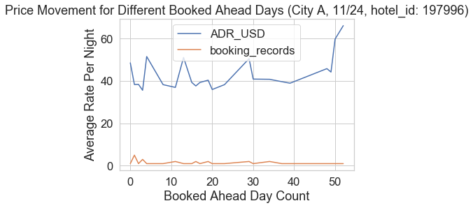

```python
exA_thanksblack_1124_ahead_ADR_pophotel[['ADR_USD', 'booking_records']].plot()
plt.xlabel("Booked Ahead Day Count")
plt.ylabel("Average Rate Per Night");
plt.title("Price Movement for Different Booked Ahead Days (City A, 11/24, hotel_id: 197996)")
```

No obvious result. Maybe it's because this is a hotel that doesn't have a lot of price change. In this case, let's try another holiday with another hotel.

### One Hotel For Christmas Long Weekend

```python
##### 12/23/2016
exA_christmas_1223 = exA_christmas[exA_christmas['checkin_date'] == christmas[0]]
pop_hotel_1223 = exA_christmas_1223.groupby(exA_christmas_1223['hotel_id']).agg('count')['#'].sort_values(ascending = False).head(1).index[0]
pop_hotel_1223
# Still the SAME HOTEL: hotel_id = 197996, it's a low rate Hotel!
#Let's try the 2nd popular hotel and see if there is a more obvious differnece in the price
pop_hotel_1223_2nd = exA_christmas_1223.groupby(exA_christmas_1223['hotel_id']).agg('count')['#'].sort_values(ascending = False).index[1]
exA_christmas_1223_ahead_ADR_pophotel_2nd = exA_christmas_1223[exA_christmas_1223['hotel_id'] == pop_hotel_1223_2nd].groupby([exA_christmas_1223['bookdays_int']]).agg('mean').iloc[:, [1, 4, 5]]
exA_christmas_1223_ahead_ADR_pophotel_2nd['booking_records'] = exA_christmas_1223[exA_christmas_1223['hotel_id'] == pop_hotel_1223_2nd].groupby('bookdays_int').agg('count')['#']
exA_christmas_1223_ahead_ADR_pophotel_2nd
```

| bookdays_int | ADR_USD | star_rating | booking_month | booking_records |
| --- | --- | --- | --- | --- |
| 1 | 138.840000 | 4.0 | 12.0 | 1 |
| 2 | 122.740000 | 4.0 | 12.0 | 2 |
| 3 | 114.520000 | 4.0 | 12.0 | 1 |
| 5 | 110.140000 | 4.0 | 12.0 | 1 |
| 8 | 123.640000 | 4.0 | 12.0 | 2 |
| 10 | 125.806667 | 4.0 | 12.0 | 3 |
| 15 | 117.933333 | 4.0 | 12.0 | 1 |
| 16 | 123.980000 | 4.0 | 12.0 | 1 |
| 17 | 108.220000 | 4.0 | 12.0 | 1 |
| 19 | 110.000000 | 4.0 | 12.0 | 1 |
| 21 | 120.660000 | 4.0 | 12.0 | 1 |
| 26 | 116.600000 | 4.0 | 11.0 | 1 |
| 32 | 118.080000 | 4.0 | 11.0 | 1 |
| 38 | 122.170000 | 4.0 | 11.0 | 1 |
| 47 | 110.380000 | 4.0 | 11.0 | 1 |
| 49 | 110.620000 | 4.0 | 11.0 | 1 |
| 60 | 110.140000 | 4.0 | 10.0 | 1 |

### 2nd Popular hotel on 12/23/2016 (hotel_id = 21272)

Now we have the 2nd poplular hotel on 12/23/2016. This is a hotel that has a higher rate compare to the previous one. This might give us a more obvious affect in the price movement.

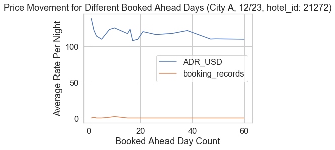

```python
exA_christmas_1223_ahead_ADR_pophotel_2nd[['ADR_USD', 'booking_records']].plot(kind = 'line')
plt.xlabel("Booked Ahead Day Count")
plt.ylabel("Average Rate Per Night");
plt.title("Price Movement for Different Booked Ahead Days (City A, 12/23, hotel_id: 21272)")
```

**There is a obvious increase in price when the booking date approaches the checkin date (12/23)**  
Let's take a look at another day.

### 2nd Popular hotel on 12/25/2016 (hotel_id = 21272)

```python
##### 12/25/2016
exA_christmas_1225 = exA_christmas[exA_christmas['checkin_date'] == christmas[2]]
pop_hotel_1225 = exA_christmas_1225.groupby(exA_christmas_1225['hotel_id']).agg('count')['#'].sort_values(ascending = False).head(1).index[0]
pop_hotel_1225
exA_christmas_1225.groupby(exA_christmas_1225['hotel_id']).agg('count')['#'].sort_values(ascending = False).head()
# Still the SAME HOTEL: hotel_id = 197996, it's a low rate Hotel!
#Let's try the 2nd popular hotel and see if there is a more obvious differnece in the price

pop_hotel_1223_2nd = exA_christmas_1223.groupby(exA_christmas_1223['hotel_id']).agg('count')['#'].sort_values(ascending = False).index[1]

exA_christmas_1225_ahead_ADR_pophotel_2nd = exA_christmas_1225[exA_christmas_1225['hotel_id'] == pop_hotel_1223_2nd].groupby([exA_christmas_1225['bookdays_int']]).agg('mean').iloc[:, [1, 4, 5]]
exA_christmas_1225_ahead_ADR_pophotel_2nd['booking_records'] = exA_christmas_1225[exA_christmas_1225['hotel_id'] == pop_hotel_1223_2nd].groupby('bookdays_int').agg('count')['#']
exA_christmas_1225_ahead_ADR_pophotel_2nd
```

| bookdays_int | ADR_USD | star_rating | booking_month | booking_records |
| --- | --- | --- | --- | --- |
| 0 | 121.500000 | 4.0 | 12.0 | 1 |
| 1 | 117.680000 | 4.0 | 12.0 | 2 |
| 2 | 129.880000 | 4.0 | 12.0 | 1 |
| 3 | 125.533333 | 4.0 | 12.0 | 2 |
| 6 | 121.960000 | 4.0 | 12.0 | 1 |
| 8 | 104.046667 | 4.0 | 12.0 | 1 |
| 10 | 110.940000 | 4.0 | 12.0 | 1 |
| 11 | 119.140000 | 4.0 | 12.0 | 1 |
| 12 | 119.080000 | 4.0 | 12.0 | 1 |
| 13 | 111.940000 | 4.0 | 12.0 | 2 |
| 19 | 117.720000 | 4.0 | 12.0 | 1 |
| 22 | 121.460000 | 4.0 | 12.0 | 1 |
| 39 | 143.520000 | 4.0 | 11.0 | 1 |

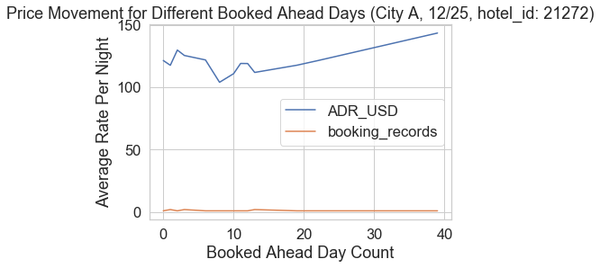

```python
exA_christmas_1225_ahead_ADR_pophotel_2nd[['ADR_USD', 'booking_records']].plot(kind = 'line')
plt.xlabel("Booked Ahead Day Count")
plt.ylabel("Average Rate Per Night");
plt.title("Price Movement for Different Booked Ahead Days (City A, 12/25, hotel_id: 21272)")
```

### 3rd Popular hotel on 12/23/2016 (hotel_id = 297388)

```python
##### 12/23/2016
exA_christmas_1223 = exA_christmas[exA_christmas['checkin_date'] == christmas[0]]
pop_hotel_1223_3rd = exA_christmas_1223.groupby(exA_christmas_1223['hotel_id']).agg('count')['#'].sort_values(ascending = False).index[2]
pop_hotel_1223_3rd

# exA_christmas_1223_ahead_ADR_pophotel_3rd = exA_christmas_1223[exA_christmas_1223['hotel_id'] == pop_hotel_1223_3rd].groupby([exA_christmas_1223['bookdays_int']]).agg('mean').iloc[:, [1, 4, 5]]
# exA_christmas_1223_ahead_ADR_pophotel_3rd['booking_records'] = exA_christmas_1223[exA_christmas_1223['hotel_id'] == pop_hotel_1223_3rd].groupby('bookdays_int').agg('count')['#']
# exA_christmas_1223_ahead_ADR_pophotel_3rd
```

```
297388
```

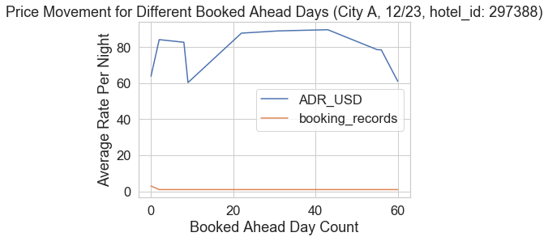

```python
exA_christmas_1223_ahead_ADR_pophotel_3rd[['ADR_USD', 'booking_records']].plot(kind = 'line')
plt.xlabel("Booked Ahead Day Count")
plt.ylabel("Average Rate Per Night");
plt.title("Price Movement for Different Booked Ahead Days (City A, 12/23, hotel_id: 297388)")
```

The plot seems so weird because the booking amount for this hotel (297388) on that day doesn't have a lot of data. Therefore very sensitive for small change.